# IMDB Sentiment-Analyse: Naive Bayes vs. LSTM

Dieses Notebook lädt das IMDB-Dataset aus dem Ordner `Data/` und trainiert zwei Klassifikatoren: einen klassischen Ansatz (TF-IDF + Naive Bayes) und ein Deep-Learning-Modell (LSTM). Zum Schluss vergleichen wir Metriken, Laufzeit und Interpretierbarkeit und geben Empfehlungen.

Hinweis: Die Zellen sind so gestaltet, dass das Notebook auf einem typischen Studenten-Laptop lauffähig ist (begrenzte Vokabulargröße, wenige Epochen).

```python
# Section 1: Imports und Einstellungen
import os
import random
import time
import numpy as np
import pandas as pd
import matplotlib.pyplot as plt
import seaborn as sns
from sklearn.model_selection import train_test_split
from sklearn.feature_extraction.text import TfidfVectorizer
from sklearn.naive_bayes import MultinomialNB
from sklearn.pipeline import Pipeline
from sklearn import metrics
import joblib
import nltk
from nltk.corpus import stopwords
import re
# TensorFlow / Keras
import tensorflow as tf
from tensorflow import keras
from tensorflow.keras.preprocessing.text import Tokenizer
from tensorflow.keras.preprocessing.sequence import pad_sequences
from tensorflow.keras.models import Sequential
from tensorflow.keras.layers import Embedding, LSTM, Dense, Bidirectional, Dropout
from tensorflow.keras.callbacks import EarlyStopping, ModelCheckpoint

# Reproduzierbarkeit
SEED = 42
random.seed(SEED)
np.random.seed(SEED)
tf.random.set_seed(SEED)

# Zeige Versionen
print('pandas', pd.__version__)
print('numpy', np.__version__)
print('tensorflow', tf.__version__)
```

```
pandas 2.3.3
numpy 2.3.5
tensorflow 2.20.0
```

```python
# Section 2: Daten laden (robustes Snippet)
data_path = os.path.join('Data', 'IMDB Dataset.csv')
if not os.path.exists(data_path):
    raise FileNotFoundError(f'Datei nicht gefunden: {data_path} - stelle sicher, dass sie im Ordner Data/ liegt')

df = pd.read_csv(data_path)
print('Shape:', df.shape)
display(df.head(5))
display(df.info())
```

```
Shape: (50000, 2)
```

|  | review | sentiment |
| --- | --- | --- |
| 0 | One of the other reviewers has mentioned that ... | positive |
| 1 | A wonderful little production. <br /><br />The... | positive |
| 2 | I thought this was a wonderful way to spend ti... | positive |
| 3 | Basically there's a family where a little boy ... | negative |
| 4 | Petter Mattei's "Love in the Time of Money" is... | positive |

```
<class 'pandas.core.frame.DataFrame'>
RangeIndex: 50000 entries, 0 to 49999
Data columns (total 2 columns):
 #   Column     Non-Null Count  Dtype
---  ------     --------------  -----
 0   review     50000 non-null  object
 1   sentiment  50000 non-null  object
dtypes: object(2)
memory usage: 781.4+ KB
```

```
None
```

```
sentiment
positive    25000
negative    25000
Name: count, dtype: int64
```

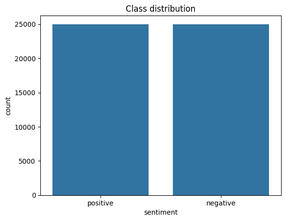

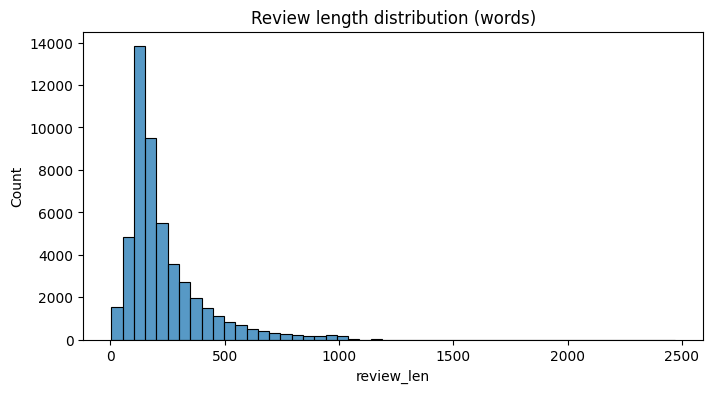

```python
# Section 3: EDA - Klassenverteilung & Längenverteilung
if 'sentiment' in df.columns and 'review' in df.columns:
    display(df['sentiment'].value_counts())
    sns.countplot(data=df, x='sentiment')
    plt.title('Class distribution')
    plt.show()
    df['review_len'] = df['review'].apply(lambda x: len(str(x).split()))
    plt.figure(figsize=(8,4))
    sns.histplot(df['review_len'], bins=50)
    plt.title('Review length distribution (words)')
    plt.show()
else:
    print('Erwarte Spalten `review` und `sentiment` im Dataset')
```

```python
# Section 4: Preprocessing - clean_text Funktion
nltk.download('stopwords')
STOPWORDS = set(stopwords.words('english'))

def clean_text(text, remove_stopwords=True):
    if not isinstance(text, str):
        text = str(text)
    # HTML entfernen
    text = re.sub(r'<.*?>', ' ', text)
    # non-letters entfernen
    text = re.sub(r'[^a-zA-Z]', ' ', text)
    text = text.lower()
    tokens = text.split()
    if remove_stopwords:
        tokens = [t for t in tokens if t not in STOPWORDS]
    return ' '.join(tokens)

# Sample Anwendung (erst nur auf kleinen Subset um Zeit zu sparen)
df['clean_review'] = df['review'].astype(str).str[:500].apply(clean_text)  # safe apply
display(df[['review','clean_review']].head())
```

|  | review | clean_review |
| --- | --- | --- |
| 0 | One of the other reviewers has mentioned that ... | one reviewers mentioned watching oz episode ho... |
| 1 | A wonderful little production. <br /><br />The... | wonderful little production filming technique ... |
| 2 | I thought this was a wonderful way to spend ti... | thought wonderful way spend time hot summer we... |
| 3 | Basically there's a family where a little boy ... | basically family little boy jake thinks zombie... |
| 4 | Petter Mattei's "Love in the Time of Money" is... | petter mattei love time money visually stunnin... |

```python
# Label-Encoding und train/test split (Section 4/6)
label_map = {'positive':1, 'negative':0}
df['label'] = df['sentiment'].map(label_map)
X = df['clean_review']
y = df['label']
X_train, X_test, y_train, y_test = train_test_split(X, y, test_size=0.2, stratify=y, random_state=SEED)
print('Train/Test sizes:', X_train.shape, X_test.shape)
```

```
Train/Test sizes: (40000,) (10000,)
```

### Modell 1: TF-IDF + Naive Bayes (klassischer Ansatz)

Wir verwenden `TfidfVectorizer` + `MultinomialNB`. Dieser Ansatz ist schnell, gut interpretierbar (Top-Features) und für Bag-of-Words-Textklassifikation häufig sehr effektiv.

```python
# Utility: Metriken-Funktion
from sklearn.metrics import accuracy_score, precision_score, recall_score, f1_score, confusion_matrix, classification_report

def compute_metrics(y_true, y_pred):
    acc = accuracy_score(y_true, y_pred)
    prec = precision_score(y_true, y_pred)
    rec = recall_score(y_true, y_pred)
    f1 = f1_score(y_true, y_pred)
    return {'accuracy': acc, 'precision': prec, 'recall': rec, 'f1': f1}

def plot_confusion(y_true, y_pred, labels=[0,1], title='Confusion Matrix'):
    cm = confusion_matrix(y_true, y_pred, labels=labels)
    plt.figure(figsize=(5,4))
    sns.heatmap(cm, annot=True, fmt='d', cmap='Blues')
    plt.xlabel('Predicted')
    plt.ylabel('True')
    plt.title(title)
    plt.show()
```

```
Training Naive Bayes took 3.89 sec
Naive Bayes results: {'accuracy': 0.8298, 'precision': 0.8213172252533125, 'recall': 0.843, 'f1': 0.8320173707066719}
Classification report:               precision    recall  f1-score   support

           0       0.84      0.82      0.83      5000
           1       0.82      0.84      0.83      5000

    accuracy                           0.83     10000
   macro avg       0.83      0.83      0.83     10000
weighted avg       0.83      0.83      0.83     10000

Naive Bayes results: {'accuracy': 0.8298, 'precision': 0.8213172252533125, 'recall': 0.843, 'f1': 0.8320173707066719}
Classification report:               precision    recall  f1-score   support

           0       0.84      0.82      0.83      5000
           1       0.82      0.84      0.83      5000

    accuracy                           0.83     10000
   macro avg       0.83      0.83      0.83     10000
weighted avg       0.83      0.83      0.83     10000
```

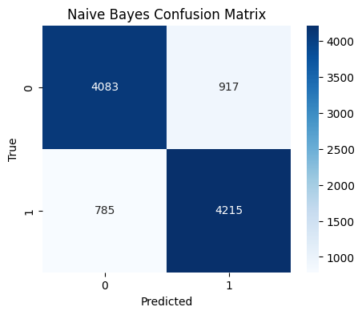

```
NB pipeline saved to nb_pipeline.joblib
```

```python
# Section 6: Train Naive Bayes
from sklearn.feature_extraction.text import TfidfVectorizer
from sklearn.naive_bayes import MultinomialNB

nb_pipeline = Pipeline([
    ('tfidf', TfidfVectorizer(
        max_features=50000,        # bigger vocab
        ngram_range=(1, 2),        # keep bigrams
        min_df=2,                  # ignore super-rare words
        max_df=0.95,               # ignore extremely common tokens
        sublinear_tf=True,         # log-scaling of term frequency
        stop_words='english'
    )),
    ('nb', MultinomialNB(alpha=0.5))  # slightly stronger smoothing
])

t0 = time.time()
nb_pipeline.fit(X_train, y_train)
t1 = time.time()
print(f'Training Naive Bayes took {t1-t0:.2f} sec')
y_pred_nb = nb_pipeline.predict(X_test)
metrics_nb = compute_metrics(y_test, y_pred_nb)
print('Naive Bayes results:', metrics_nb)
print('Classification report:', classification_report(y_test, y_pred_nb))
plot_confusion(y_test, y_pred_nb, title='Naive Bayes Confusion Matrix')
# Speichere Modell
joblib.dump(nb_pipeline, 'nb_pipeline.joblib')
print('NB pipeline saved to nb_pipeline.joblib')
```

### Modell 2: LSTM (Deep Learning)

Wir erstellen ein einfaches LSTM-Modell mit Embedding-Layer. Längere Trainingszeit und höhere Rechenkosten können auftreten; deshalb begrenzen wir Vokabulargröße und Epochen.

BiLSTM + GloVe -> Glove uses data from wikipedia and is not focused on Movie reviews

```
Example training review:
 caught little gem totally accident back revival theatre see two old silly sci fi movies theatre packed full warning showed bunch sci fi short spoofs get us mood somewhat amusing came within seconds audience hysterics biggest laugh came showed princess laia huge cinnamon buns instead hair head looks
Example training sequence (first 30 tokens): [707, 42, 1075, 307, 1248, 56, 6346, 1131, 11, 38, 55, 507, 557, 471, 17, 1131, 2149, 243, 1417, 897, 552, 557, 471, 203, 6202, 22, 100, 1208, 563, 1020]
Train tensor shape: (40000, 300)
Test tensor shape: (10000, 300)
y_train class distribution: [20000 20000]
y_test class distribution: [5000 5000]
Loading GloVe embeddings from glove.6B.100d.txt
Loaded word vectors: 400000
Embedding matrix shape: (50000, 100)
Words without GloVe vector: 6952
```

```
f:\FHTechnikum\Semester 5\NLP\venv\Lib\site-packages\keras\src\layers\core\embedding.py:97: UserWarning: Argument `input_length` is deprecated. Just remove it.
  warnings.warn(
f:\FHTechnikum\Semester 5\NLP\venv\Lib\site-packages\keras\src\layers\activations\leaky_relu.py:41: UserWarning: Argument `alpha` is deprecated. Use `negative_slope` instead.
  warnings.warn(
```

```
Model: "functional_1"
```

```
┏━━━━━━━━━━━━━━━━━━━━━━━━━━━━━━━━━┳━━━━━━━━━━━━━━━━━━━━━━━━┳━━━━━━━━━━━━━━━┓
┃ Layer (type)                    ┃ Output Shape           ┃       Param # ┃
┡━━━━━━━━━━━━━━━━━━━━━━━━━━━━━━━━━╇━━━━━━━━━━━━━━━━━━━━━━━━╇━━━━━━━━━━━━━━━┩
│ input_layer_1 (InputLayer)      │ (None, 300)            │             0 │
├─────────────────────────────────┼────────────────────────┼───────────────┤
│ embedding_1 (Embedding)         │ (None, 300, 100)       │     5,000,000 │
├─────────────────────────────────┼────────────────────────┼───────────────┤
│ bidirectional_2 (Bidirectional) │ (None, 300, 256)       │       234,496 │
├─────────────────────────────────┼────────────────────────┼───────────────┤
│ dropout_2 (Dropout)             │ (None, 300, 256)       │             0 │
├─────────────────────────────────┼────────────────────────┼───────────────┤
│ bidirectional_3 (Bidirectional) │ (None, 128)            │       164,352 │
├─────────────────────────────────┼────────────────────────┼───────────────┤
│ dense_2 (Dense)                 │ (None, 64)             │         8,256 │
├─────────────────────────────────┼────────────────────────┼───────────────┤
│ leaky_re_lu_1 (LeakyReLU)       │ (None, 64)             │             0 │
├─────────────────────────────────┼────────────────────────┼───────────────┤
│ dropout_3 (Dropout)             │ (None, 64)             │             0 │
├─────────────────────────────────┼────────────────────────┼───────────────┤
│ dense_3 (Dense)                 │ (None, 1)              │            65 │
└─────────────────────────────────┴────────────────────────┴───────────────┘
```

```
 Total params: 5,407,169 (20.63 MB)
```

```
 Trainable params: 5,407,169 (20.63 MB)
```

```
 Non-trainable params: 0 (0.00 B)
```

```
500/500 ━━━━━━━━━━━━━━━━━━━━ 232s 460ms/step - accuracy: 0.7275 - loss: 0.5400 - val_accuracy: 0.7797 - val_loss: 0.4637
500/500 ━━━━━━━━━━━━━━━━━━━━ 250s 501ms/step - accuracy: 0.8030 - loss: 0.4349 - val_accuracy: 0.7983 - val_loss: 0.4212
500/500 ━━━━━━━━━━━━━━━━━━━━ 261s 522ms/step - accuracy: 0.8366 - loss: 0.3722 - val_accuracy: 0.8165 - val_loss: 0.3989
500/500 ━━━━━━━━━━━━━━━━━━━━ 261s 523ms/step - accuracy: 0.8663 - loss: 0.3188 - val_accuracy: 0.8215 - val_loss: 0.4032
500/500 ━━━━━━━━━━━━━━━━━━━━ 261s 522ms/step - accuracy: 0.8942 - loss: 0.2689 - val_accuracy: 0.8219 - val_loss: 0.4485
Training BiLSTM + GloVe took 1265.24 sec
40/40 ━━━━━━━━━━━━━━━━━━━━ 15s 373ms/step
Prediction on test set took 15.19 sec
Predicted probabilities: min = 0.008283955976366997 max = 0.9918140172958374 mean = 0.49866485595703125
y_pred_bilstm_glove class distribution: [4877 5123]
BiLSTM + GloVe results: {'accuracy': 0.8169, 'precision': 0.8092914308022643, 'recall': 0.8292, 'f1': 0.8191247653857552}
Classification report:
               precision    recall  f1-score   support

         0.0       0.82      0.80      0.81      5000
         1.0       0.81      0.83      0.82      5000

    accuracy                           0.82     10000
   macro avg       0.82      0.82      0.82     10000
weighted avg       0.82      0.82      0.82     10000
```

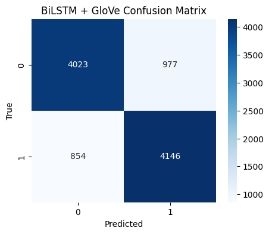

```
WARNING:absl:You are saving your model as an HDF5 file via `model.save()` or `keras.saving.save_model(model)`. This file format is considered legacy. We recommend using instead the native Keras format, e.g. `model.save('my_model.keras')` or `keras.saving.save_model(model, 'my_model.keras')`.
```

```
BiLSTM + GloVe model saved to bilstm_glove_imdb_model.h5
Tokenizer saved to tokenizer_bilstm_glove.joblib
```

```python
# Section 8: BiLSTM + GloVe Embeddings on IMDB

import time
import os
import numpy as np
import tensorflow as tf
from tensorflow.keras.preprocessing.text import Tokenizer
from tensorflow.keras.preprocessing.sequence import pad_sequences
from tensorflow.keras import layers
import joblib

# Tokenisierung & Padding

MAX_WORDS = 50000   # Vokabulargröße
MAX_LEN   = 300
EMBED_DIM = 100

# Sicherstellen, dass X_train / X_test Strings sind
X_train_text = X_train.astype(str)
X_test_text  = X_test.astype(str)

# Tokenizer nur auf Trainingsdaten fitten
tokenizer = Tokenizer(num_words=MAX_WORDS, oov_token="<OOV>")
tokenizer.fit_on_texts(X_train_text)

# Texte -> Integer-Sequenzen
X_train_seq = tokenizer.texts_to_sequences(X_train_text)
X_test_seq  = tokenizer.texts_to_sequences(X_test_text)

print("Example training review:\n", X_train_text.iloc[0][:300])
print("Example training sequence (first 30 tokens):", X_train_seq[0][:30])

# Padding auf gleiche Länge
X_train_pad = pad_sequences(
    X_train_seq, maxlen=MAX_LEN,
    padding='post', truncating='post'
)
X_test_pad = pad_sequences(
    X_test_seq, maxlen=MAX_LEN,
    padding='post', truncating='post'
)

print("Train tensor shape:", X_train_pad.shape)
print("Test tensor shape:", X_test_pad.shape)

# Labels in numpy-Arrays (float32) umwandeln
y_train_arr = np.asarray(y_train).astype("float32")
y_test_arr  = np.asarray(y_test).astype("float32")

print("y_train class distribution:", np.bincount(y_train_arr.astype("int32")))
print("y_test class distribution:", np.bincount(y_test_arr.astype("int32")))

# -------------------------------------------------
# 2) GloVe-Embeddings laden & Embedding-Matrix bauen
# -------------------------------------------------
# Pfad zur GloVe-Datei (passe an, falls sie woanders liegt)
GLOVE_PATH = "glove.6B.100d.txt"

if not os.path.exists(GLOVE_PATH):
    raise FileNotFoundError(
        f"{GLOVE_PATH} not found. "
        "Download GloVe 6B (100d) and place glove.6B.100d.txt in the working directory."
    )

print("Loading GloVe embeddings from", GLOVE_PATH)

embeddings_index = {}
with open(GLOVE_PATH, "r", encoding="utf8") as f:
    for line in f:
        values = line.strip().split()
        word = values[0]
        coefs = np.asarray(values[1:], dtype="float32")
        embeddings_index[word] = coefs

print("Loaded word vectors:", len(embeddings_index))

word_index = tokenizer.word_index
num_words = min(MAX_WORDS, len(word_index) + 1)

embedding_matrix = np.zeros((num_words, EMBED_DIM), dtype="float32")
missing = 0

for word, i in word_index.items():
    if i >= MAX_WORDS:
        continue
    embedding_vector = embeddings_index.get(word)
    if embedding_vector is not None:
        embedding_matrix[i] = embedding_vector
    else:
        # Wort nicht im GloVe-Vokabular
        missing += 1

print(f"Embedding matrix shape: {embedding_matrix.shape}")
print(f"Words without GloVe vector: {missing}")

# Embedding-Layer mit GloVe initialisieren
embedding_layer = layers.Embedding(
    input_dim=num_words,
    output_dim=EMBED_DIM,
    weights=[embedding_matrix],
    input_length=MAX_LEN,
    trainable=True  # erst einfrieren, später ggf. True setzen für Fine-Tuning
)

# -------------------------------------------------
# 3) BiLSTM-Modell definieren (mit GloVe)
# -------------------------------------------------
inputs = tf.keras.Input(shape=(MAX_LEN,), dtype="int32")
x = embedding_layer(inputs)

x = layers.Bidirectional(
    layers.LSTM(128, return_sequences=True)
)(x)
x = layers.Dropout(0.3)(x)

x = layers.Bidirectional(
    layers.LSTM(64)
)(x)

x = layers.Dense(64)(x)
x = layers.LeakyReLU(alpha=0.1)(x)
x = layers.Dropout(0.4)(x)

outputs = layers.Dense(1, activation="sigmoid")(x)

model = tf.keras.Model(inputs=inputs, outputs=outputs)

model.compile(
    loss="binary_crossentropy",
    optimizer=tf.keras.optimizers.Adam(learning_rate=2e-4),
    metrics=["accuracy"]
)

model.summary()

# -------------------------------------------------
# 4) Training mit EarlyStopping
# -------------------------------------------------
batch_size = 64
epochs = 10

early_stop = tf.keras.callbacks.EarlyStopping(
    monitor="val_loss",
    patience=2,
    restore_best_weights=True
)

t0 = time.time()
history = model.fit(
    X_train_pad, y_train_arr,
    batch_size=batch_size,
    epochs=epochs,
    validation_split=0.2,
    callbacks=[early_stop],
    verbose=1
)
t1 = time.time()
print(f"Training BiLSTM + GloVe took {t1 - t0:.2f} sec")

# -------------------------------------------------
# 5) Evaluation auf dem Testset
# -------------------------------------------------
t0 = time.time()
y_pred_proba = model.predict(X_test_pad, batch_size=256)
t1 = time.time()
print(f"Prediction on test set took {t1 - t0:.2f} sec")

print("Predicted probabilities: min =", float(y_pred_proba.min()),
      "max =", float(y_pred_proba.max()),
      "mean =", float(y_pred_proba.mean()))

# Wahrscheinlichkeiten -> Klassen (0/1)
y_pred_bilstm_glove = (y_pred_proba >= 0.5).astype("int32").ravel()

print("y_pred_bilstm_glove class distribution:",
      np.bincount(y_pred_bilstm_glove))

# -------------------------------------------------
# 6) Metriken & Confusion Matrix
# -------------------------------------------------
metrics_bilstm_glove = compute_metrics(y_test_arr, y_pred_bilstm_glove)
print("BiLSTM + GloVe results:", metrics_bilstm_glove)
print("Classification report:\n",
      classification_report(y_test_arr, y_pred_bilstm_glove))

plot_confusion(y_test_arr, y_pred_bilstm_glove,
               title="BiLSTM + GloVe Confusion Matrix")

# -------------------------------------------------
# 7) Modell & Tokenizer speichern
# -------------------------------------------------
model.save("bilstm_glove_imdb_model.h5")
joblib.dump(tokenizer, "tokenizer_bilstm_glove.joblib")
print("BiLSTM + GloVe model saved to bilstm_glove_imdb_model.h5")
print("Tokenizer saved to tokenizer_bilstm_glove.joblib")

# Optional: falls ihr eine 'results'-Liste habt:
# results.append({
#     'model': 'BiLSTM + GloVe',
#     **metrics_bilstm_glove
# })
```

LSTM (andom Embeddings)

```python
# Section 7: Tokenisierung und Sequenzvorbereitung
MAX_NUM_WORDS = 20000
MAX_LEN = 200
tokenizer = Tokenizer(num_words=MAX_NUM_WORDS, oov_token='<OOV>')
tokenizer.fit_on_texts(X_train)
X_train_seq = tokenizer.texts_to_sequences(X_train)
X_test_seq = tokenizer.texts_to_sequences(X_test)
X_train_pad = pad_sequences(X_train_seq, maxlen=MAX_LEN, padding='post', truncating='post')
X_test_pad = pad_sequences(X_test_seq, maxlen=MAX_LEN, padding='post', truncating='post')
print('Vocabulary size (approx):', min(MAX_NUM_WORDS, len(tokenizer.word_index)))
print('X_train_pad shape:', X_train_pad.shape)
```

```
Vocabulary size (approx): 20000
X_train_pad shape: (40000, 200)
```

```python
# Section 8: LSTM Modellaufbau und Training
EMBEDDING_DIM = 100
model = Sequential([
    Embedding(input_dim=MAX_NUM_WORDS, output_dim=EMBEDDING_DIM, input_length=MAX_LEN),
    Bidirectional(LSTM(64, dropout=0.2, recurrent_dropout=0.2)),
    Dense(32, activation='relu'),
    Dropout(0.3),
    Dense(1, activation='sigmoid')
])
model.compile(loss='binary_crossentropy', optimizer='adam', metrics=['accuracy'])
model.summary()
# Callbacks
es = EarlyStopping(monitor='val_loss', patience=2, restore_best_weights=True)
# train (keeping epochs small for student machines)
t0 = time.time()
history = model.fit(X_train_pad, y_train, epochs=5, batch_size=128,
                    validation_split=0.1, callbacks=[es], verbose=1)
t1 = time.time()
print(f'LSTM training took {t1-t0:.2f} sec')
# Speichere Modell und Tokenizer
model.save('lstm_model.h5')
joblib.dump(tokenizer, 'tokenizer.joblib')
print('LSTM model and tokenizer saved')
```

```
f:\FHTechnikum\Semester 5\NLP\venv\Lib\site-packages\keras\src\layers\core\embedding.py:97: UserWarning: Argument `input_length` is deprecated. Just remove it.
  warnings.warn(
```

```
Model: "sequential"
```

```
┏━━━━━━━━━━━━━━━━━━━━━━━━━━━━━━━━━┳━━━━━━━━━━━━━━━━━━━━━━━━┳━━━━━━━━━━━━━━━┓
┃ Layer (type)                    ┃ Output Shape           ┃       Param # ┃
┡━━━━━━━━━━━━━━━━━━━━━━━━━━━━━━━━━╇━━━━━━━━━━━━━━━━━━━━━━━━╇━━━━━━━━━━━━━━━┩
│ embedding_2 (Embedding)         │ ?                      │   0 (unbuilt) │
├─────────────────────────────────┼────────────────────────┼───────────────┤
│ bidirectional_4 (Bidirectional) │ ?                      │   0 (unbuilt) │
├─────────────────────────────────┼────────────────────────┼───────────────┤
│ dense_4 (Dense)                 │ ?                      │   0 (unbuilt) │
├─────────────────────────────────┼────────────────────────┼───────────────┤
│ dropout_4 (Dropout)             │ ?                      │             0 │
├─────────────────────────────────┼────────────────────────┼───────────────┤
│ dense_5 (Dense)                 │ ?                      │   0 (unbuilt) │
└─────────────────────────────────┴────────────────────────┴───────────────┘
```

```
 Total params: 0 (0.00 B)
```

```
 Trainable params: 0 (0.00 B)
```

```
 Non-trainable params: 0 (0.00 B)
```

```
282/282 ━━━━━━━━━━━━━━━━━━━━ 117s 403ms/step - accuracy: 0.7540 - loss: 0.4947 - val_accuracy: 0.8342 - val_loss: 0.3726
282/282 ━━━━━━━━━━━━━━━━━━━━ 113s 403ms/step - accuracy: 0.8743 - loss: 0.3151 - val_accuracy: 0.8347 - val_loss: 0.3763
282/282 ━━━━━━━━━━━━━━━━━━━━ 113s 400ms/step - accuracy: 0.9087 - loss: 0.2430 - val_accuracy: 0.8310 - val_loss: 0.4291
```

```
WARNING:absl:You are saving your model as an HDF5 file via `model.save()` or `keras.saving.save_model(model)`. This file format is considered legacy. We recommend using instead the native Keras format, e.g. `model.save('my_model.keras')` or `keras.saving.save_model(model, 'my_model.keras')`.
```

```
LSTM training took 342.79 sec
LSTM model and tokenizer saved
```

```
79/79 ━━━━━━━━━━━━━━━━━━━━ 3s 30ms/step
LSTM results: {'accuracy': 0.8247, 'precision': 0.8218037661050545, 'recall': 0.8292, 'f1': 0.8254853160776505}
Classification report:               precision    recall  f1-score   support

           0       0.83      0.82      0.82      5000
           1       0.82      0.83      0.83      5000

    accuracy                           0.82     10000
   macro avg       0.82      0.82      0.82     10000
weighted avg       0.82      0.82      0.82     10000
```

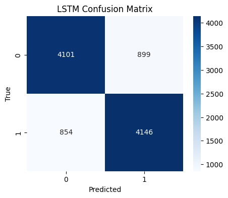

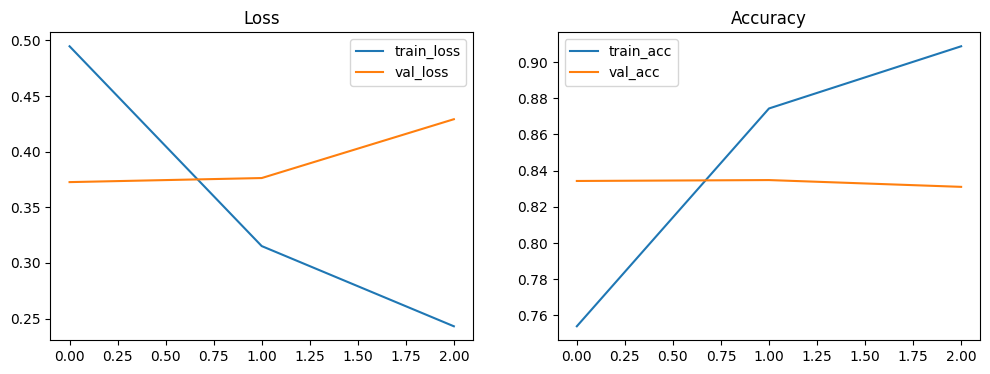

```python
# Section 10: Evaluation LSTM
y_probs = model.predict(X_test_pad, batch_size=128)
y_pred_lstm = (y_probs.flatten() >= 0.5).astype(int)
metrics_lstm = compute_metrics(y_test, y_pred_lstm)
print('LSTM results:', metrics_lstm)
print('Classification report:', classification_report(y_test, y_pred_lstm))
plot_confusion(y_test, y_pred_lstm, title='LSTM Confusion Matrix')
# Plot Training History
plt.figure(figsize=(12,4))
plt.subplot(1,2,1)
plt.plot(history.history['loss'], label='train_loss')
plt.plot(history.history['val_loss'], label='val_loss')
plt.legend(); plt.title('Loss')
plt.subplot(1,2,2)
plt.plot(history.history['accuracy'], label='train_acc')
plt.plot(history.history['val_accuracy'], label='val_acc')
plt.legend(); plt.title('Accuracy')
plt.show()
```

```python
# Section 11: Vergleich beider Modelle in einer Tabelle
results = pd.DataFrame([
    {'model':'NaiveBayes', **metrics_nb},
    {'model':'LSTM', **metrics_lstm}
])
display(results)
results.to_csv('model_comparison.csv', index=False)
print('Vergleich gespeichert als model_comparison.csv')
```

|  | model | accuracy | precision | recall | f1 |
| --- | --- | --- | --- | --- | --- |
| 0 | NaiveBayes | 0.8298 | 0.821317 | 0.8430 | 0.832017 |
| 1 | LSTM | 0.8247 | 0.821804 | 0.8292 | 0.825485 |

```
Vergleich gespeichert als model_comparison.csv
```

### Interpretation & Diskussion (kurz)

- Naive Bayes ist sehr schnell, interpretiert durch Top-Features (TF-IDF Gewichtungen).
- LSTM kann Kontext und Reihenfolge lernen, ist aber rechenaufwändiger und benötigt mehr Daten oder Regularisierung, um nicht zu überfitten.
- Wenn NB ähnliche oder bessere Metriken liefert, ist der klassische Ansatz für Produktions-Einsätze oft ausreichend; andernfalls lohnt sich Fein-Tuning oder der Einsatz vortrainierter Embeddings/Transformer.

```python
# Section 12: Top-Features aus NB anzeigen (Interpretierbarkeit)
tfidf = nb_pipeline.named_steps['tfidf']
nb = nb_pipeline.named_steps['nb']
feature_names = tfidf.get_feature_names_out()
class0_top = np.argsort(nb.feature_log_prob_[0])[-20:]
class1_top = np.argsort(nb.feature_log_prob_[1])[-20:]
print('Top features negative:')
print(feature_names[class0_top])
print('Top features positive:')
print(feature_names[class1_top])
```

```
Top features negative:
['way' 'know' 'think' 'watch' 'characters' 'make' 'seen' 'people' 'worst'
 'story' 'time' 'movies' 'acting' 'plot' 'really' 'good' 'like' 'bad'
 'film' 'movie']
Top features positive:
['characters' 'way' 'watch' 'years' 'think' 'life' 'films' 'movies'
 'people' 'seen' 'love' 'really' 'best' 'time' 'good' 'like' 'story'
 'great' 'film' 'movie']
```

### Reproduzierbarkeit & Hinzufügungen

- Modelle: `nb_pipeline.joblib`, `lstm_model.h5`, `tokenizer.joblib` wurden gespeichert.
- Paketversionen oben ausgeben; für vollständige Reproduzierbarkeit siehe `requirements.txt`.
- Für weitergehende Verbesserungen: Hyperparameter-Tuning (GridSearchCV für NB-Pipeline), pretrained embeddings (GloVe), oder Transformer-Modelle (z.B. DistilBERT).

## How to run

1. Installiere Abhängigkeiten: `pip install -r requirements.txt`
2. Öffne dieses Notebook in VS Code oder Jupyter und führe Zellen nacheinander aus.
3. Falls NLTK-Stopwords nicht vorhanden sind, wird der Download in einer Zelle ausgeführt.